# Part I - Prosper Loan Data

## Preliminary Wrangling

```python
# import all packages and set plots to be embedded inline
import numpy as np
import pandas as pd
import matplotlib.pyplot as plt
import seaborn as sb

%matplotlib inline
```

### Load the dataset

```python
# load in the dataset into a pandas dataframe, print statistics
df = pd.read_csv('prosperLoanData.csv')
df.head()
```

|  | ListingKey | ListingNumber | ListingCreationDate | CreditGrade | Term | LoanStatus | ClosedDate | BorrowerAPR | BorrowerRate | LenderYield | ... | LP_ServiceFees | LP_CollectionFees | LP_GrossPrincipalLoss | LP_NetPrincipalLoss | LP_NonPrincipalRecoverypayments | PercentFunded | Recommendations | InvestmentFromFriendsCount | InvestmentFromFriendsAmount | Investors |
| --- | --- | --- | --- | --- | --- | --- | --- | --- | --- | --- | --- | --- | --- | --- | --- | --- | --- | --- | --- | --- | --- |
| 0 | 1021339766868145413AB3B | 193129 | 2007-08-26 19:09:29.263000000 | C | 36 | Completed | 2009-08-14 00:00:00 | 0.16516 | 0.1580 | 0.1380 | ... | -133.18 | 0.0 | 0.0 | 0.0 | 0.0 | 1.0 | 0 | 0 | 0.0 | 258 |
| 1 | 10273602499503308B223C1 | 1209647 | 2014-02-27 08:28:07.900000000 | NaN | 36 | Current | NaN | 0.12016 | 0.0920 | 0.0820 | ... | 0.00 | 0.0 | 0.0 | 0.0 | 0.0 | 1.0 | 0 | 0 | 0.0 | 1 |
| 2 | 0EE9337825851032864889A | 81716 | 2007-01-05 15:00:47.090000000 | HR | 36 | Completed | 2009-12-17 00:00:00 | 0.28269 | 0.2750 | 0.2400 | ... | -24.20 | 0.0 | 0.0 | 0.0 | 0.0 | 1.0 | 0 | 0 | 0.0 | 41 |
| 3 | 0EF5356002482715299901A | 658116 | 2012-10-22 11:02:35.010000000 | NaN | 36 | Current | NaN | 0.12528 | 0.0974 | 0.0874 | ... | -108.01 | 0.0 | 0.0 | 0.0 | 0.0 | 1.0 | 0 | 0 | 0.0 | 158 |
| 4 | 0F023589499656230C5E3E2 | 909464 | 2013-09-14 18:38:39.097000000 | NaN | 36 | Current | NaN | 0.24614 | 0.2085 | 0.1985 | ... | -60.27 | 0.0 | 0.0 | 0.0 | 0.0 | 1.0 | 0 | 0 | 0.0 | 20 |

5 rows × 81 columns

### Dataset view

#### data shape

```python
df.shape
```

```
(113937, 81)
```

#### columns

```python
df.columns
```

```
Index(['ListingKey', 'ListingNumber', 'ListingCreationDate', 'CreditGrade',
       'Term', 'LoanStatus', 'ClosedDate', 'BorrowerAPR', 'BorrowerRate',
       'LenderYield', 'EstimatedEffectiveYield', 'EstimatedLoss',
       'EstimatedReturn', 'ProsperRating (numeric)', 'ProsperRating (Alpha)',
       'ProsperScore', 'ListingCategory (numeric)', 'BorrowerState',
       'Occupation', 'EmploymentStatus', 'EmploymentStatusDuration',
       'IsBorrowerHomeowner', 'CurrentlyInGroup', 'GroupKey',
       'DateCreditPulled', 'CreditScoreRangeLower', 'CreditScoreRangeUpper',
       'FirstRecordedCreditLine', 'CurrentCreditLines', 'OpenCreditLines',
       'TotalCreditLinespast7years', 'OpenRevolvingAccounts',
       'OpenRevolvingMonthlyPayment', 'InquiriesLast6Months', 'TotalInquiries',
       'CurrentDelinquencies', 'AmountDelinquent', 'DelinquenciesLast7Years',
       'PublicRecordsLast10Years', 'PublicRecordsLast12Months',
       'RevolvingCreditBalance', 'BankcardUtilization',
       'AvailableBankcardCredit', 'TotalTrades',
       'TradesNeverDelinquent (percentage)', 'TradesOpenedLast6Months',
       'DebtToIncomeRatio', 'IncomeRange', 'IncomeVerifiable',
       'StatedMonthlyIncome', 'LoanKey', 'TotalProsperLoans',
       'TotalProsperPaymentsBilled', 'OnTimeProsperPayments',
       'ProsperPaymentsLessThanOneMonthLate',
       'ProsperPaymentsOneMonthPlusLate', 'ProsperPrincipalBorrowed',
       'ProsperPrincipalOutstanding', 'ScorexChangeAtTimeOfListing',
       'LoanCurrentDaysDelinquent', 'LoanFirstDefaultedCycleNumber',
       'LoanMonthsSinceOrigination', 'LoanNumber', 'LoanOriginalAmount',
       'LoanOriginationDate', 'LoanOriginationQuarter', 'MemberKey',
       'MonthlyLoanPayment', 'LP_CustomerPayments',
       'LP_CustomerPrincipalPayments', 'LP_InterestandFees', 'LP_ServiceFees',
       'LP_CollectionFees', 'LP_GrossPrincipalLoss', 'LP_NetPrincipalLoss',
       'LP_NonPrincipalRecoverypayments', 'PercentFunded', 'Recommendations',
       'InvestmentFromFriendsCount', 'InvestmentFromFriendsAmount',
       'Investors'],
      dtype='object')
```

#### data types

```python
df.dtypes
```

```
ListingKey                      object
ListingNumber                    int64
ListingCreationDate             object
CreditGrade                     object
Term                             int64
                                ...
PercentFunded                  float64
Recommendations                  int64
InvestmentFromFriendsCount       int64
InvestmentFromFriendsAmount    float64
Investors                        int64
Length: 81, dtype: object
```

```python
# convert ProsperRating into ordered categorical type
ordinal_var = {'ProsperRating (Alpha)': ['AA','A','B','C','D','E','HR']} # dict of ordinal variables
for var in ordinal_var:
    ordered_var = pd.api.types.CategoricalDtype(ordered = True, categories = ordinal_var[var])
    df_loans[var] = df_loans[var].astype(ordered_var)
```

#### Overview of the first and last 5 rows

```python
df.head()
```

|  | ListingKey | ListingNumber | ListingCreationDate | CreditGrade | Term | LoanStatus | ClosedDate | BorrowerAPR | BorrowerRate | LenderYield | ... | LP_ServiceFees | LP_CollectionFees | LP_GrossPrincipalLoss | LP_NetPrincipalLoss | LP_NonPrincipalRecoverypayments | PercentFunded | Recommendations | InvestmentFromFriendsCount | InvestmentFromFriendsAmount | Investors |
| --- | --- | --- | --- | --- | --- | --- | --- | --- | --- | --- | --- | --- | --- | --- | --- | --- | --- | --- | --- | --- | --- |
| 0 | 1021339766868145413AB3B | 193129 | 2007-08-26 19:09:29.263000000 | C | 36 | Completed | 2009-08-14 00:00:00 | 0.16516 | 0.1580 | 0.1380 | ... | -133.18 | 0.0 | 0.0 | 0.0 | 0.0 | 1.0 | 0 | 0 | 0.0 | 258 |
| 1 | 10273602499503308B223C1 | 1209647 | 2014-02-27 08:28:07.900000000 | NaN | 36 | Current | NaN | 0.12016 | 0.0920 | 0.0820 | ... | 0.00 | 0.0 | 0.0 | 0.0 | 0.0 | 1.0 | 0 | 0 | 0.0 | 1 |
| 2 | 0EE9337825851032864889A | 81716 | 2007-01-05 15:00:47.090000000 | HR | 36 | Completed | 2009-12-17 00:00:00 | 0.28269 | 0.2750 | 0.2400 | ... | -24.20 | 0.0 | 0.0 | 0.0 | 0.0 | 1.0 | 0 | 0 | 0.0 | 41 |
| 3 | 0EF5356002482715299901A | 658116 | 2012-10-22 11:02:35.010000000 | NaN | 36 | Current | NaN | 0.12528 | 0.0974 | 0.0874 | ... | -108.01 | 0.0 | 0.0 | 0.0 | 0.0 | 1.0 | 0 | 0 | 0.0 | 158 |
| 4 | 0F023589499656230C5E3E2 | 909464 | 2013-09-14 18:38:39.097000000 | NaN | 36 | Current | NaN | 0.24614 | 0.2085 | 0.1985 | ... | -60.27 | 0.0 | 0.0 | 0.0 | 0.0 | 1.0 | 0 | 0 | 0.0 | 20 |

5 rows × 81 columns

```python
df.tail()
```

|  | ListingKey | ListingNumber | ListingCreationDate | CreditGrade | Term | LoanStatus | ClosedDate | BorrowerAPR | BorrowerRate | LenderYield | ... | LP_ServiceFees | LP_CollectionFees | LP_GrossPrincipalLoss | LP_NetPrincipalLoss | LP_NonPrincipalRecoverypayments | PercentFunded | Recommendations | InvestmentFromFriendsCount | InvestmentFromFriendsAmount | Investors |
| --- | --- | --- | --- | --- | --- | --- | --- | --- | --- | --- | --- | --- | --- | --- | --- | --- | --- | --- | --- | --- | --- |
| 113932 | E6D9357655724827169606C | 753087 | 2013-04-14 05:55:02.663000000 | NaN | 36 | Current | NaN | 0.22354 | 0.1864 | 0.1764 | ... | -75.58 | 0.0 | 0.0 | 0.0 | 0.0 | 1.0 | 0 | 0 | 0.0 | 1 |
| 113933 | E6DB353036033497292EE43 | 537216 | 2011-11-03 20:42:55.333000000 | NaN | 36 | FinalPaymentInProgress | NaN | 0.13220 | 0.1110 | 0.1010 | ... | -30.05 | 0.0 | 0.0 | 0.0 | 0.0 | 1.0 | 0 | 0 | 0.0 | 22 |
| 113934 | E6E13596170052029692BB1 | 1069178 | 2013-12-13 05:49:12.703000000 | NaN | 60 | Current | NaN | 0.23984 | 0.2150 | 0.2050 | ... | -16.91 | 0.0 | 0.0 | 0.0 | 0.0 | 1.0 | 0 | 0 | 0.0 | 119 |
| 113935 | E6EB3531504622671970D9E | 539056 | 2011-11-14 13:18:26.597000000 | NaN | 60 | Completed | 2013-08-13 00:00:00 | 0.28408 | 0.2605 | 0.2505 | ... | -235.05 | 0.0 | 0.0 | 0.0 | 0.0 | 1.0 | 0 | 0 | 0.0 | 274 |
| 113936 | E6ED3600409833199F711B7 | 1140093 | 2014-01-15 09:27:37.657000000 | NaN | 36 | Current | NaN | 0.13189 | 0.1039 | 0.0939 | ... | -1.70 | 0.0 | 0.0 | 0.0 | 0.0 | 1.0 | 0 | 0 | 0.0 | 1 |

5 rows × 81 columns

#### Randome Overview of 5 rows

```python
df.sample(5)
```

|  | ListingKey | ListingNumber | ListingCreationDate | CreditGrade | Term | LoanStatus | ClosedDate | BorrowerAPR | BorrowerRate | LenderYield | ... | LP_ServiceFees | LP_CollectionFees | LP_GrossPrincipalLoss | LP_NetPrincipalLoss | LP_NonPrincipalRecoverypayments | PercentFunded | Recommendations | InvestmentFromFriendsCount | InvestmentFromFriendsAmount | Investors |
| --- | --- | --- | --- | --- | --- | --- | --- | --- | --- | --- | --- | --- | --- | --- | --- | --- | --- | --- | --- | --- | --- |
| 9726 | A47B3366425272400655BB5 | 6241 | 2006-04-16 15:11:58.910000000 | AA | 36 | Completed | 2007-01-17 00:00:00 | 0.08784 | 0.0810 | 0.0760 | ... | -16.05 | 0.0 | 0.0 | 0.0 | 0.0 | 1.0 | 0 | 0 | 0.0 | 56 |
| 56717 | 1C3C35022363790064186AC | 486340 | 2010-12-01 05:36:49.760000000 | NaN | 36 | Completed | 2011-04-25 00:00:00 | 0.11904 | 0.0980 | 0.0880 | ... | -34.42 | 0.0 | 0.0 | 0.0 | 0.0 | 1.0 | 0 | 0 | 0.0 | 294 |
| 64320 | FD2135952866461912D7D3D | 1072491 | 2013-12-04 20:23:05.247000000 | NaN | 36 | Current | NaN | 0.06726 | 0.0605 | 0.0505 | ... | -15.09 | 0.0 | 0.0 | 0.0 | 0.0 | 1.0 | 0 | 0 | 0.0 | 1 |
| 23075 | AF4034252485622971D188A | 354906 | 2008-06-21 17:50:02.047000000 | A | 36 | Completed | 2011-05-27 00:00:00 | 0.31765 | 0.3019 | 0.2919 | ... | -371.35 | 0.0 | 0.0 | 0.0 | 0.0 | 1.0 | 0 | 0 | 0.0 | 131 |
| 6940 | 07C8352374615359333397D | 524242 | 2011-08-29 09:10:04.257000000 | NaN | 36 | Current | NaN | 0.09333 | 0.0899 | 0.0799 | ... | -130.77 | 0.0 | 0.0 | 0.0 | 0.0 | 1.0 | 0 | 0 | 0.0 | 189 |

5 rows × 81 columns

#### Statisitical infomrmation for numerics

```python
# descriptive statistics for numeric variables
df.describe()
```

|  | ListingNumber | Term | BorrowerAPR | BorrowerRate | LenderYield | EstimatedEffectiveYield | EstimatedLoss | EstimatedReturn | ProsperRating (numeric) | ProsperScore | ... | LP_ServiceFees | LP_CollectionFees | LP_GrossPrincipalLoss | LP_NetPrincipalLoss | LP_NonPrincipalRecoverypayments | PercentFunded | Recommendations | InvestmentFromFriendsCount | InvestmentFromFriendsAmount | Investors |
| --- | --- | --- | --- | --- | --- | --- | --- | --- | --- | --- | --- | --- | --- | --- | --- | --- | --- | --- | --- | --- | --- |
| count | 1.139370e+05 | 113937.000000 | 113912.000000 | 113937.000000 | 113937.000000 | 84853.000000 | 84853.000000 | 84853.000000 | 84853.000000 | 84853.000000 | ... | 113937.000000 | 113937.000000 | 113937.000000 | 113937.000000 | 113937.000000 | 113937.000000 | 113937.000000 | 113937.000000 | 113937.000000 | 113937.000000 |
| mean | 6.278857e+05 | 40.830248 | 0.218828 | 0.192764 | 0.182701 | 0.168661 | 0.080306 | 0.096068 | 4.072243 | 5.950067 | ... | -54.725641 | -14.242698 | 700.446342 | 681.420499 | 25.142686 | 0.998584 | 0.048027 | 0.023460 | 16.550751 | 80.475228 |
| std | 3.280762e+05 | 10.436212 | 0.080364 | 0.074818 | 0.074516 | 0.068467 | 0.046764 | 0.030403 | 1.673227 | 2.376501 | ... | 60.675425 | 109.232758 | 2388.513831 | 2357.167068 | 275.657937 | 0.017919 | 0.332353 | 0.232412 | 294.545422 | 103.239020 |
| min | 4.000000e+00 | 12.000000 | 0.006530 | 0.000000 | -0.010000 | -0.182700 | 0.004900 | -0.182700 | 1.000000 | 1.000000 | ... | -664.870000 | -9274.750000 | -94.200000 | -954.550000 | 0.000000 | 0.700000 | 0.000000 | 0.000000 | 0.000000 | 1.000000 |
| 25% | 4.009190e+05 | 36.000000 | 0.156290 | 0.134000 | 0.124200 | 0.115670 | 0.042400 | 0.074080 | 3.000000 | 4.000000 | ... | -73.180000 | 0.000000 | 0.000000 | 0.000000 | 0.000000 | 1.000000 | 0.000000 | 0.000000 | 0.000000 | 2.000000 |
| 50% | 6.005540e+05 | 36.000000 | 0.209760 | 0.184000 | 0.173000 | 0.161500 | 0.072400 | 0.091700 | 4.000000 | 6.000000 | ... | -34.440000 | 0.000000 | 0.000000 | 0.000000 | 0.000000 | 1.000000 | 0.000000 | 0.000000 | 0.000000 | 44.000000 |
| 75% | 8.926340e+05 | 36.000000 | 0.283810 | 0.250000 | 0.240000 | 0.224300 | 0.112000 | 0.116600 | 5.000000 | 8.000000 | ... | -13.920000 | 0.000000 | 0.000000 | 0.000000 | 0.000000 | 1.000000 | 0.000000 | 0.000000 | 0.000000 | 115.000000 |
| max | 1.255725e+06 | 60.000000 | 0.512290 | 0.497500 | 0.492500 | 0.319900 | 0.366000 | 0.283700 | 7.000000 | 11.000000 | ... | 32.060000 | 0.000000 | 25000.000000 | 25000.000000 | 21117.900000 | 1.012500 | 39.000000 | 33.000000 | 25000.000000 | 1189.000000 |

8 rows × 61 columns

```python
df.info()
```

```
<class 'pandas.core.frame.DataFrame'>
RangeIndex: 113937 entries, 0 to 113936
Data columns (total 81 columns):
ListingKey                             113937 non-null object
ListingNumber                          113937 non-null int64
ListingCreationDate                    113937 non-null object
CreditGrade                            28953 non-null object
Term                                   113937 non-null int64
LoanStatus                             113937 non-null object
ClosedDate                             55089 non-null object
BorrowerAPR                            113912 non-null float64
BorrowerRate                           113937 non-null float64
LenderYield                            113937 non-null float64
EstimatedEffectiveYield                84853 non-null float64
EstimatedLoss                          84853 non-null float64
EstimatedReturn                        84853 non-null float64
ProsperRating (numeric)                84853 non-null float64
ProsperRating (Alpha)                  84853 non-null object
ProsperScore                           84853 non-null float64
ListingCategory (numeric)              113937 non-null int64
BorrowerState                          108422 non-null object
Occupation                             110349 non-null object
EmploymentStatus                       111682 non-null object
EmploymentStatusDuration               106312 non-null float64
IsBorrowerHomeowner                    113937 non-null bool
CurrentlyInGroup                       113937 non-null bool
GroupKey                               13341 non-null object
DateCreditPulled                       113937 non-null object
CreditScoreRangeLower                  113346 non-null float64
CreditScoreRangeUpper                  113346 non-null float64
FirstRecordedCreditLine                113240 non-null object
CurrentCreditLines                     106333 non-null float64
OpenCreditLines                        106333 non-null float64
TotalCreditLinespast7years             113240 non-null float64
OpenRevolvingAccounts                  113937 non-null int64
OpenRevolvingMonthlyPayment            113937 non-null float64
InquiriesLast6Months                   113240 non-null float64
TotalInquiries                         112778 non-null float64
CurrentDelinquencies                   113240 non-null float64
AmountDelinquent                       106315 non-null float64
```

[output cut: 31 more lines]

```
LP_CustomerPayments                    113937 non-null float64
LP_CustomerPrincipalPayments           113937 non-null float64
LP_InterestandFees                     113937 non-null float64
LP_ServiceFees                         113937 non-null float64
LP_CollectionFees                      113937 non-null float64
LP_GrossPrincipalLoss                  113937 non-null float64
LP_NetPrincipalLoss                    113937 non-null float64
LP_NonPrincipalRecoverypayments        113937 non-null float64
PercentFunded                          113937 non-null float64
Recommendations                        113937 non-null int64
InvestmentFromFriendsCount             113937 non-null int64
InvestmentFromFriendsAmount            113937 non-null float64
Investors                              113937 non-null int64
dtypes: bool(3), float64(50), int64(11), object(17)
memory usage: 68.1+ MB
```

#### Key summary from the exploratory analysis

- Timestamp of LoanOriginationDate columns have data types of object instead of datetime
- Missing values for rows with datetime before 2009 - drop null values in 'ProsperRating (Alpha)' column
- Missing values for *TotalProsperLoans* columns- fill with zero(0) values indicating the *borrower had no prior loans.*

#### Selecting variables for the analysis and visualizations

```python
columns =  [
    'Term', 'LoanStatus', 'BorrowerRate', 'ProsperRating (Alpha)', 'ListingCategory (numeric)', 'EmploymentStatus', 'CurrentDelinquencies',
     'StatedMonthlyIncome', 'TotalProsperLoans',
    'LoanOriginationDate','LoanOriginalAmount', 'Recommendations', 'Investors'
]
```

```python
df_loans = df[columns]
df_loans.head()
```

|  | Term | LoanStatus | BorrowerRate | ProsperRating (Alpha) | ListingCategory (numeric) | EmploymentStatus | CurrentDelinquencies | StatedMonthlyIncome | TotalProsperLoans | LoanOriginationDate | LoanOriginalAmount | Recommendations | Investors |
| --- | --- | --- | --- | --- | --- | --- | --- | --- | --- | --- | --- | --- | --- |
| 0 | 36 | Completed | 0.1580 | NaN | 0 | Self-employed | 2.0 | 3083.333333 | NaN | 2007-09-12 00:00:00 | 9425 | 0 | 258 |
| 1 | 36 | Current | 0.0920 | A | 2 | Employed | 0.0 | 6125.000000 | NaN | 2014-03-03 00:00:00 | 10000 | 0 | 1 |
| 2 | 36 | Completed | 0.2750 | NaN | 0 | Not available | 1.0 | 2083.333333 | NaN | 2007-01-17 00:00:00 | 3001 | 0 | 41 |
| 3 | 36 | Current | 0.0974 | A | 16 | Employed | 4.0 | 2875.000000 | NaN | 2012-11-01 00:00:00 | 10000 | 0 | 158 |
| 4 | 36 | Current | 0.2085 | D | 2 | Employed | 0.0 | 9583.333333 | 1.0 | 2013-09-20 00:00:00 | 15000 | 0 | 20 |

### Data cleaning

Performing data cleaing for the Identified issues from the exploratory analysis

#### Define: Remove missing values rows

Prosper rating values are mostly null for the period before July 2009

#### Code

```python
# check rows with LoanOriginationDate before July 2009
df_loans[df_loans['LoanOriginationDate'] <='2009-07-00 00:00:00'].sample(5)
```

[output not shown]

```python
# drop null values and reset index
df_loans = df_loans.dropna(subset=['ProsperRating (Alpha)'], axis=0).reset_index();
```

#### Test

```python
df_loans[df_loans['LoanOriginationDate'] <='2009-07-00 00:00:00']
```

#### Define: Fill null values of TotalProsperLoans columns with 0

Null values indicates the borrower had no prior loans. So we need to fill them with zero(0) values

#### Code

```python
# fill  null values with 0
df_loans['TotalProsperLoans'] = df_loans['TotalProsperLoans'].fillna(0)
```

#### Test

```python
df_loans[df_loans['TotalProsperLoans'].isnull()]
```

|  | index | Term | LoanStatus | BorrowerRate | ProsperRating (Alpha) | ListingCategory (numeric) | EmploymentStatus | CurrentDelinquencies | StatedMonthlyIncome | TotalProsperLoans | LoanOriginationDate | LoanOriginalAmount | Recommendations | Investors |
| --- | --- | --- | --- | --- | --- | --- | --- | --- | --- | --- | --- | --- | --- | --- |

#### Define: convert `LoanOriginationDate` data type from object to datetime

#### Code

```python
# check data type- shows as object
df_loans.dtypes['LoanOriginationDate']
```

```
dtype('O')
```

```python
df_loans['LoanOriginationDate'] = df_loans['LoanOriginationDate'].astype('datetime64')
```

#### Test

```python
df_loans['LoanOriginationDate'].dtypes
```

```
dtype('<M8[ns]')
```

#### Confirming that we don't have anomalies that need to be cleaned

```python
# get the statistical overview of the data, we can see same number of non-null values, and correct data types for our selected variables
df_loans.info()
```

[output not shown]

### What is the structure of your dataset?

> There are 113,937 loans with 81 variables on each loan in the dataset. In the selected variables, most are numberic. They are Term, BorrowerRate, ListingCategory (numeric), StatedMonthlyIncome, TotalProsperLoans,ListingCategory (numeric), Recommendations, Investors. The selected variables LoanStatus, EmploymentStatus categorical-nominal
> - ListingCategory: 0 - Not Available, 1 - Debt Consolidation, 2 - Home Improvement, 3 - Business, 4 - Personal Loan, 5 - Student Use, 6 - Auto, 7- Other, 8 - Baby&Adoption, 9 - Boat, 10 - Cosmetic Procedure, 11 - Engagement Ring, 12 - Green Loans, 13 - Household Expenses, 14 - Large Purchases, 15 - Medical/Dental, 16 - Motorcycle, 17 - RV, 18 - Taxes, 19 - Vacation, 20 - Wedding Loans
> - ProsperRating (numeric): 0 - N/A, 1 - HR, 2 - E, 3 - D, 4 - C, 5 - B, 6 - A, 7 - AA.

### What is/are the main feature(s) of interest in your dataset?

> I am interested in finding out how employment status and ProperRating affect loan amount given and loan default

### What features in the dataset do you think will help support your investigation into your feature(s) of interest?

> I expect that employment status, ProperRating, and StatedMonthlyIncome will have effect on the loan default/completion, and loan amount given. The higer the stated monthly income,the higher the loan being given. And the better the properRating, the more likely a borrower will not default.

## Univariate Exploration

> Investigating distributions of individual variables. EmploymentStatus, StatedMonthlyIncome, LoanStatus, ListingCategory (numeric)

#### Set up global variables to use in visualization

```python
# universal setup- base color
base_color = sb.color_palette()[0]

# Helper functions

#function to setup chart title,labels, size, and xticks rotation
def fig_polish(title, xlabel, ylabel, size=(8,5), xticks=90):
    plt.figure(figsize=size)
    plt.title(title)
    plt.xlabel(xlabel)
    plt.ylabel(ylabel)
    plt.xticks(rotation = xticks);
```

### How is the distribution of Employment Status?

[figure not shown]

```python
# histogram plot of employment status distribution
bins = df_loans['EmploymentStatus'].nunique() # use the unique values as the bins
fig_polish('Count of Employment Status of a loan borrower', 'Employment status','Count')
plt.hist(data = df_loans, x = 'EmploymentStatus',bins=bins)
plt.show()
```

[figure not shown]

```python
# Investigating this further with a searbon countplot chart
fig_polish('Count of Employment Status of a loan borrower', 'Employment status','Count')
sb.countplot(data = df_loans, x = 'EmploymentStatus', color = base_color);
```

#### Summary observations from employment status

- Borrower with employment status **Employed** are the majority
- Followed my moderatly a small number of **Full-time** employed borrower
- The least group who borrowed loan are the borrower with **Part-time** employment status

### How is StatedMonthlyIncome distributed?

[figure not shown]

```python
# Plotting count of StatedMonthlyIncome on a standard scale
fig_polish('Count of Stated Monthly Income', 'Stated Monthly Income','Count', (8,5),0)
plt.hist(data = df_loans, x = 'StatedMonthlyIncome', bins = 100)
plt.show()
```

[figure not shown]

```python
# ploting on a log scale
log_binsize = 0.025
bins = 10 ** np.arange(2.4, np.log10(df_loans['StatedMonthlyIncome'].max())+log_binsize, log_binsize)
fig_polish('Count of Stated Monthly Income', 'Stated Monthly Income','Count') # call the custom polish function
plt.hist(data = df_loans, x = 'StatedMonthlyIncome', bins = bins)
plt.xscale('log') # log scale
plt.xticks([250,1e3, 5e3, 10e3, 20e3, 50e3, 100e3], [250, '1k', '5k', '10k', '20k', '50k','100k'])
plt.show()
```

### How is Loan Status distributed

```python
def loan_status_dist(rotation=90):
    # countplot of loan status distribution
    fig_polish('Count of Loan Status', 'Loan Status','Count',(10, 6),rotation) # call the custom polish function
    sb.countplot(data = df_loans, x = 'LoanStatus', color = base_color);
```

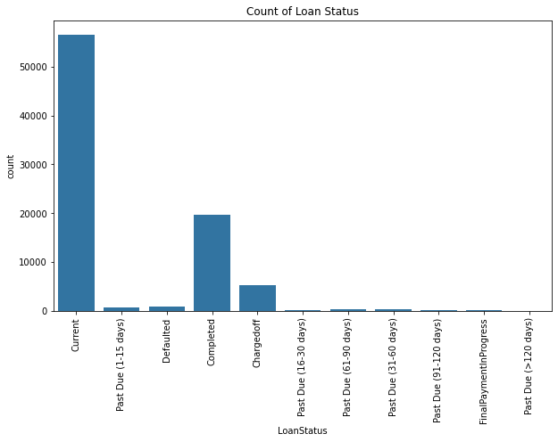

```python
# call the custom loan status function to observe distribution of loan  status
loan_status_dist()
```

#### Summary observations from Loan Status

> - We can observe that most of the loans are the **Current** ones
> - Completed loans falls the second with a count of about 20000.
> - Other loans status falls betwee 15 days and 60 days delays, while those past 120 days delays are the least occurance.
> - Since we are interested in the **loan defaulted** and **loan completed**, we will use pandas filtering to only have this two values in the next chart

Our interest is only the **loan defaulted** and **loan completed**, so we use pandas filtering to only have this two values' data

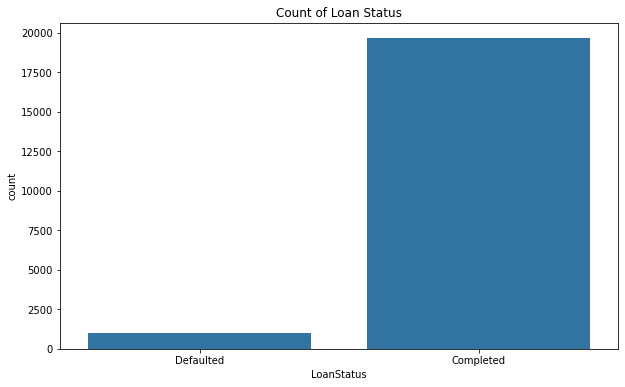

```python
# filter only loans with status Completed and Defaulted
df_loans = df_loans[(df_loans['LoanStatus']=='Completed') | (df_loans['LoanStatus']=='Defaulted')]
# call the custom loan status function and change xticks rotation to 0 since we only have 2 variables
loan_status_dist(0)
```

### Distribution of employment status, ListingCategory (numeric), and loan status on a subplot

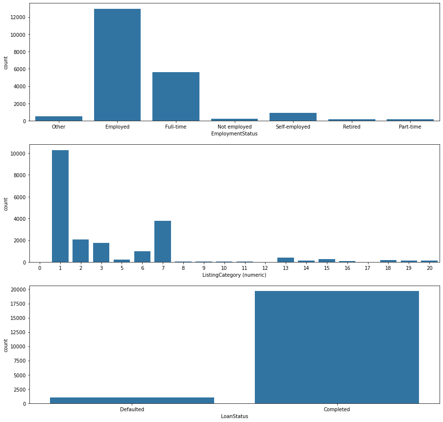

```python
# subplot distribution of employment status. listing category, and loan status
fig, ax = plt.subplots(nrows=3, figsize = [15,15]) # create subplot rows of 3
sb.countplot(data = df_loans, x = 'EmploymentStatus', color = base_color, ax = ax[0])
sb.countplot(data = df_loans, x = 'ListingCategory (numeric)', color = base_color, ax = ax[1])
sb.countplot(data = df_loans, x = 'LoanStatus', color = base_color, ax = ax[2])
plt.show()
```

### Discuss the distribution(s) of your variable(s) of interest. Were there any unusual points? Did you need to perform any transformations?

> Most of the loan borrower are employed, and the borrowing for a category listing or 1 or Debt Consolidation.

> The stated monthly income is right skewed meaning I had to perform another visualization tranforming with a logarthmic adjustment. It turns out the peak was high around 5000 monthly income.

### Of the features you investigated, were there any unusual distributions? Did you perform any operations on the data to tidy, adjust, or change the form of the data? If so, why did you do this?

> Yes, I had to clean up the dataset of null values that would cause inconsistenct in the data. I especially droped null values for properRating before July 2009

## Bivariate Exploration

### How does StatedMonthlyIncome affect LoanOriginalAmount given to borrower?

to know if having lots of income increases borrowers' loan amount

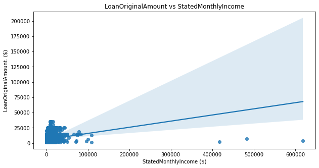

```python
# scatter plot of LoanOriginalAmount distribution against  StatedMonthlyIncome
plt.figure(figsize=(10,5))
sb.regplot(data = df_loans, x = 'StatedMonthlyIncome', y = 'LoanOriginalAmount');
plt.title('LoanOriginalAmount vs StatedMonthlyIncome')
plt.xlabel('StatedMonthlyIncome ($)')
plt.ylabel('LoanOriginalAmount. ($)');
```

#### summary of findings

> - The relationship between Loan Original Amount and Stated Monthly Income is postive correlation. An increase in the stated monthly income gradually increase the amountof loan being given
> - Concentraation of the relationship is between those with stated monthly income 0 to about 100000

### How does high LoanOriginalAmount affect LoanStatus?

To check if borrower with huge/less loan amount defaulted or completed their loan

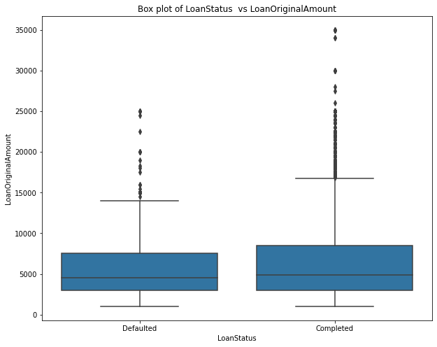

```python
# box pot of LoanOriginalAmount vs the LoanStatus
fig_polish('Box plot of LoanStatus  vs LoanOriginalAmount', 'LoanStatus','LoanOriginalAmount. ($)',(10, 8),0) # call the custom polish function
sb.boxplot(data= df_loans, x='LoanStatus', y='LoanOriginalAmount', color=base_color);
```

### How does employment status impact prosper rating, and loan status?

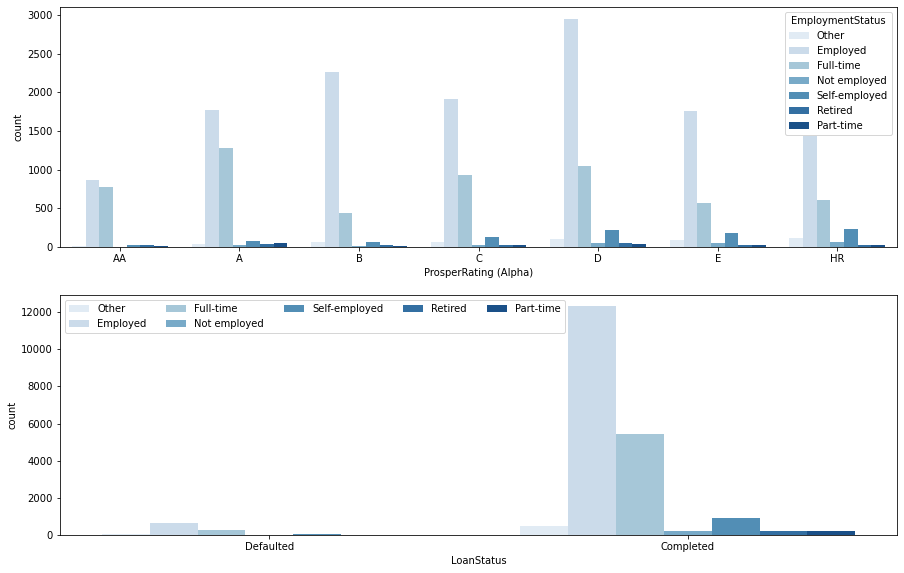

```python
# subplots of ProsperRating vs EmploymentStatus, and EmployementStatus vs LoanStatus
plt.figure(figsize = [15, 15])
# subplot 1: ProsperRating vs EmploymentStatus
plt.subplot(3, 1, 1)
sb.countplot(data = df_loans, x = 'ProsperRating (Alpha)', hue = 'EmploymentStatus', palette = 'Blues')
# subplot 2: LoanStatus vs. EmploymentStatus
ax = plt.subplot(3, 1, 2)
sb.countplot(data = df_loans, x = 'LoanStatus', hue = 'EmploymentStatus', palette = 'Blues')
ax.legend(ncol = 5);
```

### Talk about some of the relationships you observed in this part of the investigation. How did the feature(s) of interest vary with other features in the dataset?

> Borrower with a high rating are those whose employment status is either Employed or Full-time, and they complete loan repayment.

> The relationship between statedMonthlyIncome, and LoanOriginalAmount is positive correlation.

## Multivariate Exploration

> In this section I will further investigate the variables relations with employment status, and loan status

### How does LoanOriginalAmount and StatedMonthlyIncome is effected by employment status and what's the resultant loan status outcome?

Here I check how employment status variable is affected by the LoanOriginalAmount and StatedMonthlyIncome, and then subplot a loan status varaible against LoanOriginalAmount and StatedMonthlyIncome

```python
# helper function for the check the distribution of employment status and loan status against LoanOriginalAmount and StatedMonthlyIncome
def employment_loan_status(hue, axis, title):
    df_loans_sample = df_loans.head(500); # use sample 500 data to reduce execution speed and performance
    sb.pointplot(data = df_loans_sample, x = 'LoanOriginalAmount', y = 'StatedMonthlyIncome', hue = hue,
                 palette = 'Blues', linestyles = '', dodge = 0.4, ax = ax[axis])
    ax[axis].set_title(title)
    ax[axis].set_xlabel('Linear scale of LoanOriginalAmount ($)')
    ax[axis].set_ylabel('StatedMonthlyIncome ($)')
    ax[axis].set_xscale('linear')
```

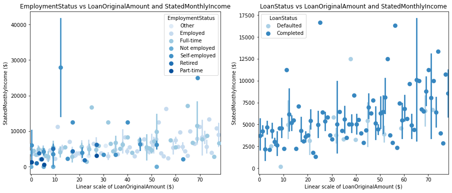

```python
# generate two subplots on axis 0 and 1
fig, ax = plt.subplots(ncols = 2, figsize = [15,6])
# fill subplot 1 on the first axis-0 using the helper function
employment_loan_status('EmploymentStatus',0,'EmploymentStatus vs LoanOriginalAmount and StatedMonthlyIncome')
# fill subplot 2 on the second axis-1 using the helper function
employment_loan_status('LoanStatus',1,'LoanStatus vs LoanOriginalAmount and StatedMonthlyIncome')
```

#### summary of the observations

Looking further with transformed charts,

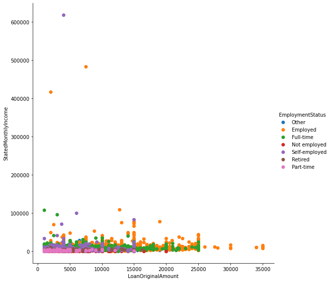

```python
# using facetGrid  and scatter plot chart to confirm our understanding of employment status against LoanOriginalAmount and StatedMonthlyIncome
g = sb.FacetGrid(data = df_loans, hue = 'EmploymentStatus', height = 8)
g.map(plt.scatter, 'LoanOriginalAmount', 'StatedMonthlyIncome')
g.add_legend();
```

> This marker scatter plot as well gives us clear understanding that employed people have the highest loan original amount given

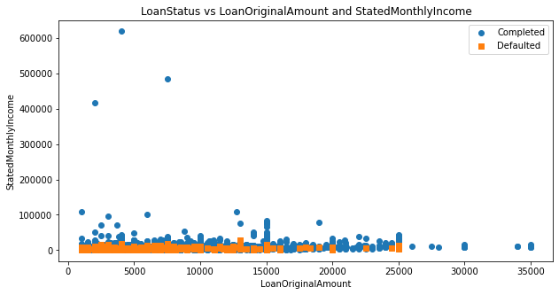

```python
# using facetGrid  and scatter plot chart to confirm our understanding of loan status against LoanOriginalAmount and StatedMonthlyIncome
loan_status = [['Completed', 'o'],['Defaulted', 's']] # using shape
fig_polish('LoanStatus vs LoanOriginalAmount and StatedMonthlyIncome', 'LoanOriginalAmount','StatedMonthlyIncome',(10, 5),0) # call the custom polish function

# get status, shape and map them to the corresponding data
for status, marker in loan_status:
    data = df_loans[df_loans['LoanStatus'] == status ]
    plt.scatter(data =data, x = 'LoanOriginalAmount', y = 'StatedMonthlyIncome', marker = marker)
plt.legend(['Completed','Defaulted']);
```

Now lets investigate how loan status is affected by ProsperRating and investors

[figure not shown]

```python
plt.figure(figsize = [10, 5])
sb.violinplot(data=df_loans, x='ProsperRating (Alpha)', y='Investors', hue='LoanStatus')
plt.title("Loan status vs ProsperRating, and LoanOriginalAmount");
```

#### summary of findings

> - People with a rating of about **A** and **AA** gets better investment from investors. This is implies more investors are willing to spend their money on crediting people with good rating and history of loan completion

### Talk about some of the relationships you observed in this part of the investigation. Were there features that strengthened each other in terms of looking at your feature(s) of interest?

> Looking through the findings in this section, The defaulted loan and completed loan were strengthened by the fact that people with good prosper rating, and large amount of loans were mostly completing their loans payment

### Were there any interesting or surprising interactions between features?

> Employed people with high monthly income almost always complete loans payments